# R Notebook

```r
median_vector <- c()
for(i in 1:1000)
{
  new_sample <- sample(airquality$Solar.R, replace = TRUE)
  new_sample <- na.omit(new_sample)
  median_vector <- c(median_vector, median(new_sample))
}
quantile_mean <- quantile(median_vector, c(0.25, 0.75))
print(paste("Confidence Interval left-side: ", quantile_mean[1]))
```

```
[1] "Confidence Interval left-side:  194"
```

```r
print(paste("Confidence Interval right-side: ", quantile_mean[2]))
```

```
[1] "Confidence Interval right-side:  220"
```

```r
se
```

```
ORDINARY NONPARAMETRIC BOOTSTRAP


Call:
boot(data = airquality$Solar.R, statistic = med, R = 1000)


Bootstrap Statistics :
    original  bias    std. error
t1*      205  0.7245    12.31123
```

[output not shown]

[output cut: 30 more lines]

```r
ships$Risk = ships$incidents > 10
ships$Risk[ships$Risk == TRUE] = "High"
ships$Risk[ships$Risk == FALSE] = "Low"
```

```r
table(ships$Risk)
```

[output not shown]

Yes because the condition of CLT(at least 30 samples) is not satisfied we need simulation.

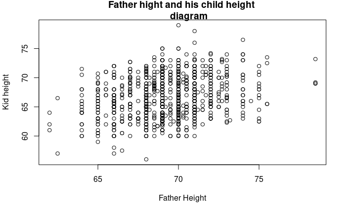

```r
print(paste("Corrolation height is: ", corr_height))
```

```
[1] "Corrolation height is:  0.275354826252148"
```

No because the correlation coeffiecent is a low number thus we couldn’t conclude strong relationship between variables.

```r
lm_height
```

```
Call:
lm(formula = Galton$height ~ Galton$father, data = Galton)

Coefficients:
  (Intercept)  Galton$father
      39.1104         0.3994
```

This variables define a line which is the best approximation for the relation between response and explanatory variable.

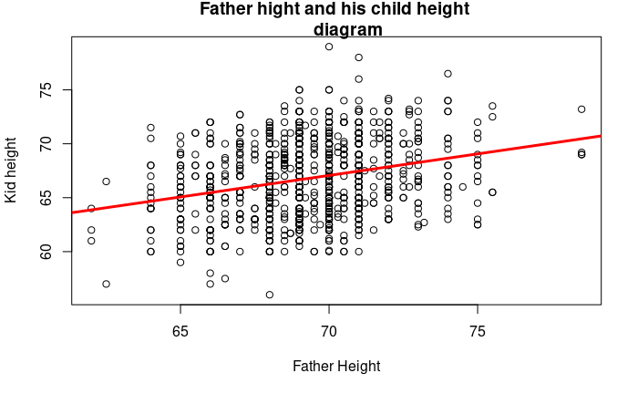

```r
plot(Galton$father, Galton$height, xlab = "Father Height", ylab = "Kid height", main = "Father hight and his child height
     diagram")
abline(39.1104, 0.3994, col = "red", lwd = 3)
```

It means when the father height is 0 what would be the kid height(It doesnt show anything most of the time).

```r
predict(lm(height ~ father, data = Galton), newdata = data.frame(father = c(70, 75, 80)))
```

```
       1        2        3
67.06708 69.06398 71.06089
```

```r
lm_height_mother <- lm(height ~ father + mother, data = Galton)
lm_height_mother
```

```
Call:
lm(formula = height ~ father + mother, data = Galton)

Coefficients:
(Intercept)       father       mother
    22.3097       0.3799       0.2832
```

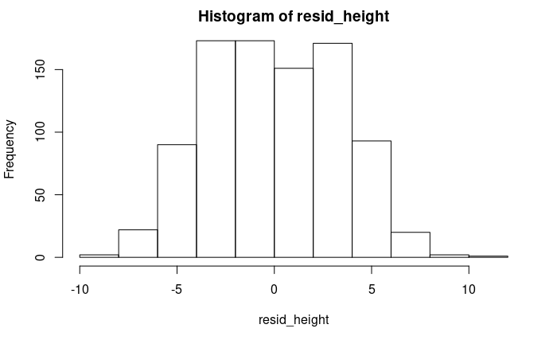

It should be similar to normal distribution

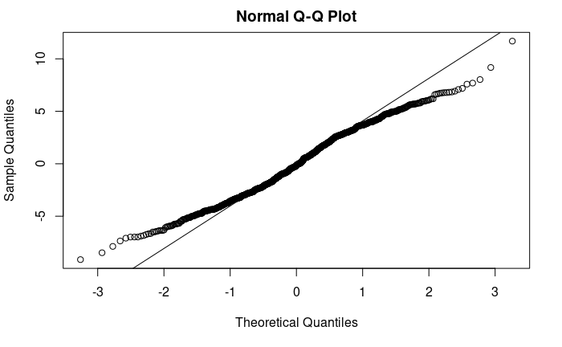

```r
qqnorm(resid_height)
qqline(resid_height)
```

By checking the Linearity of the residuals compare to normal we could check whether it is similar to normal distribution or not.

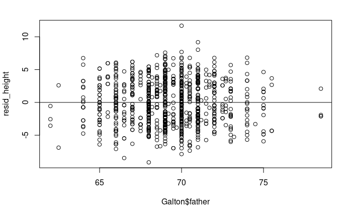

```r
plot(resid_height ~ Galton$father)
abline(0, 0)
```

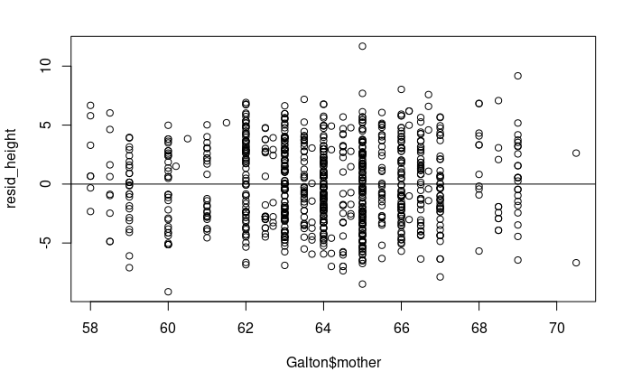

```r
plot(resid_height ~ Galton$mother)
abline(0, 0)
```

It checks the Constant Variability conditions for MLR. That is should be randomly distributed around 0.

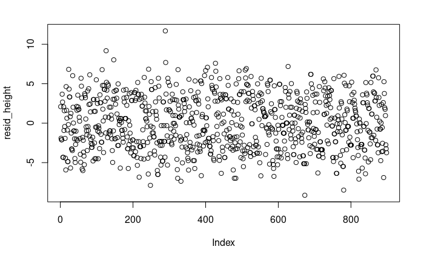

It checks Independent Residuals in MLR conditions.

```r
lm_three <- lm(Galton$height ~ Galton$father + Galton$mother + Galton$sex)
summary(lm_three)
```

```
Call:
lm(formula = Galton$height ~ Galton$father + Galton$mother +
    Galton$sex)

Residuals:
   Min     1Q Median     3Q    Max
-9.523 -1.440  0.117  1.473  9.114

Coefficients:
              Estimate Std. Error t value Pr(>|t|)
(Intercept)   15.34476    2.74696   5.586 3.08e-08 ***
Galton$father  0.40598    0.02921  13.900  < 2e-16 ***
Galton$mother  0.32150    0.03128  10.277  < 2e-16 ***
Galton$sexM    5.22595    0.14401  36.289  < 2e-16 ***
---
Signif. codes:  0 ‘***’ 0.001 ‘**’ 0.01 ‘*’ 0.05 ‘.’ 0.1 ‘ ’ 1

Residual standard error: 2.154 on 894 degrees of freedom
Multiple R-squared:  0.6397,    Adjusted R-squared:  0.6385
F-statistic:   529 on 3 and 894 DF,  p-value: < 2.2e-16
```

Yes it is statistically significant because its p-value as we can see above is less than 0.01

```r
library('MASS')
nf <- subset(Galton, select = -c(family))
lm_selection <- lm(height ~ ., data = nf)
backward_lm <- stepAIC(lm_selection, direction = "backward")
```

```
Start:  AIC=1381.77
height ~ father + mother + sex + nkids

         Df Sum of Sq     RSS    AIC
<none>                 4137.1 1381.8
- nkids   1      12.0  4149.2 1382.4
- mother  1     488.5  4625.6 1480.0
- father  1     840.8  4977.9 1545.9
- sex     1    6045.8 10182.9 2188.6
```

```r
summary(backward_lm)
```

```
Call:
lm(formula = height ~ father + mother + sex + nkids, data = nf)

Residuals:
    Min      1Q  Median      3Q     Max
-9.4748 -1.4500  0.0889  1.4716  9.1656

Coefficients:
            Estimate Std. Error t value Pr(>|t|)
(Intercept) 16.18771    2.79387   5.794 9.52e-09 ***
father       0.39831    0.02957  13.472  < 2e-16 ***
mother       0.32096    0.03126  10.269  < 2e-16 ***
sexM         5.20995    0.14422  36.125  < 2e-16 ***
nkids       -0.04382    0.02718  -1.612    0.107
---
Signif. codes:  0 ‘***’ 0.001 ‘**’ 0.01 ‘*’ 0.05 ‘.’ 0.1 ‘ ’ 1

Residual standard error: 2.152 on 893 degrees of freedom
Multiple R-squared:  0.6407,    Adjusted R-squared:  0.6391
F-statistic: 398.1 on 4 and 893 DF,  p-value: < 2.2e-16
```

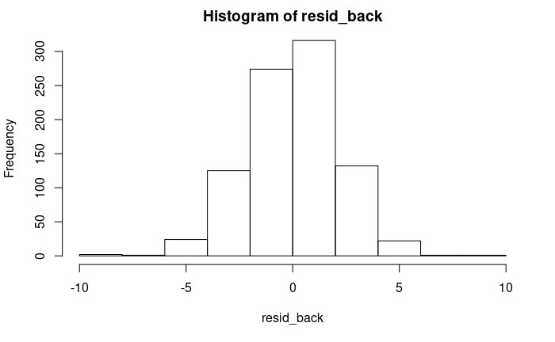

```r
resid_back <- resid(backward_lm)
hist(resid_back)
```

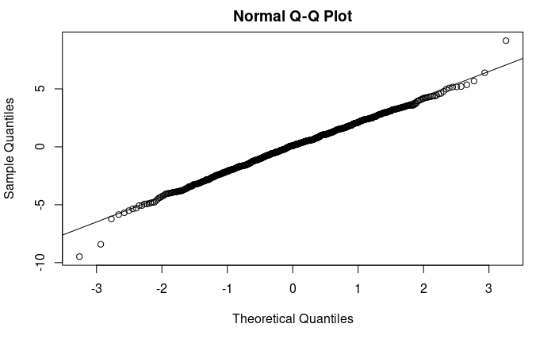

```r
qqnorm(resid_back)
qqline(resid_back)
```

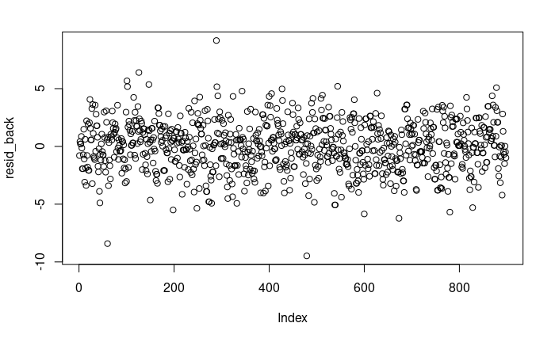

```r
plot(resid_back)
```

```r
library('COUNT')
data('titanic')
titanic$new_survived[titanic$survived == "yes"] = TRUE
titanic$new_survived[titanic$survived == "no"] = FALSE
titanic$new_survived <- factor(titanic$new_survived)
titanic <- subset(titanic, select = -c(survived))
titanic_glm <- glm(titanic$new_survived ~ ., data = titanic, family = "binomial")
summary(titanic_glm)
```

```
Call:
glm(formula = titanic$new_survived ~ ., family = "binomial",
    data = titanic)

Deviance Residuals:
    Min       1Q   Median       3Q      Max
-2.0652  -0.6718  -0.4740   0.7930   2.1175

Coefficients:
               Estimate Std. Error z value Pr(>|z|)
(Intercept)      3.0619     0.2980  10.275  < 2e-16 ***
class2nd class  -1.0106     0.1949  -5.184 2.17e-07 ***
class3rd class  -1.7664     0.1707 -10.347  < 2e-16 ***
ageadults       -1.0556     0.2427  -4.350 1.36e-05 ***
sexman          -2.3695     0.1453 -16.313  < 2e-16 ***
---
Signif. codes:  0 ‘***’ 0.001 ‘**’ 0.01 ‘*’ 0.05 ‘.’ 0.1 ‘ ’ 1

(Dispersion parameter for binomial family taken to be 1)

    Null deviance: 1746.8  on 1315  degrees of freedom
Residual deviance: 1276.2  on 1311  degrees of freedom
AIC: 1286.2

Number of Fisher Scoring iterations: 4
```

```r
person_sample <- data.frame(class = "2nd class", age = "adults", sex = "man")
predict(titanic_glm, newdata = person_sample, type = "response")
```

```
        1
0.2020148
```

```r
all_possible <- titanic %>% expand(class = c('1st class', '2nd class', '3rd class'), age, sex)
all_possible$prob_survive <- predict(titanic_glm, newdata = all_possible, type = "response")
sorted_possible <- all_possible[order(-1 * all_possible$prob_survive), ]
sorted_possible
```

| class | age | sex | prob_survive |
| --- | --- | --- | --- |
| 1st class | child | women | 0.9552927 |
| 2nd class | child | women | 0.8860813 |
| 1st class | adults | women | 0.8814542 |
| 3rd class | child | women | 0.7850784 |
| 2nd class | adults | women | 0.7302154 |
| 1st class | child | man | 0.6665043 |
| 3rd class | adults | women | 0.5596896 |
| 2nd class | child | man | 0.4211288 |
| 1st class | adults | man | 0.4101873 |
| 3rd class | child | man | 0.2546517 |

[output cut: 2 more lines]

```r
pred <- predict(titanic_glm, newdata = titanic, type = "response")
titanic$survive_pred <- pred
titanic$survive_pred2[titanic$survive_pred > 0.5] = TRUE
titanic$survive_pred2[titanic$survive_pred < 0.5] = FALSE
print(paste("precentage correct is: ", sum(titanic$survive_pred2 == titanic$new_survived) / nrow(titanic)))
```

```
[1] "precentage correct is:  0.777355623100304"
```

No is is not going to be valid because there are alot of different variable in two ships.